# Explore_bikeshare_data

### Explore Bike Share Data

For this project, your goal is to ask and answer three questions about the available bikeshare data from Washington, Chicago, and New York. This notebook can be submitted directly through the workspace when you are confident in your results.

You will be graded against the project [Rubric](https://review.udacity.com/#!/rubrics/2508/view) by a mentor after you have submitted. To get you started, you can use the template below, but feel free to be creative in your solutions!

```r
ny = read.csv('new_york_city.csv')
wash = read.csv('washington.csv')
chi = read.csv('chicago.csv')
```

```r
head(ny)
```

| X | Start.Time | End.Time | Trip.Duration | Start.Station | End.Station | User.Type | Gender | Birth.Year |
| --- | --- | --- | --- | --- | --- | --- | --- | --- |
| 5688089 | 2017-06-11 14:55:05 | 2017-06-11 15:08:21 | 795 | Suffolk St & Stanton St | W Broadway & Spring St | Subscriber | Male | 1998 |
| 4096714 | 2017-05-11 15:30:11 | 2017-05-11 15:41:43 | 692 | Lexington Ave & E 63 St | 1 Ave & E 78 St | Subscriber | Male | 1981 |
| 2173887 | 2017-03-29 13:26:26 | 2017-03-29 13:48:31 | 1325 | 1 Pl & Clinton St | Henry St & Degraw St | Subscriber | Male | 1987 |
| 3945638 | 2017-05-08 19:47:18 | 2017-05-08 19:59:01 | 703 | Barrow St & Hudson St | W 20 St & 8 Ave | Subscriber | Female | 1986 |
| 6208972 | 2017-06-21 07:49:16 | 2017-06-21 07:54:46 | 329 | 1 Ave & E 44 St | E 53 St & 3 Ave | Subscriber | Male | 1992 |
| 1285652 | 2017-02-22 18:55:24 | 2017-02-22 19:12:03 | 998 | State St & Smith St | Bond St & Fulton St | Subscriber | Male | 1986 |

```r
head(wash)
```

[output not shown]

```r
head(chi)
```

| X | Start.Time | End.Time | Trip.Duration | Start.Station | End.Station | User.Type | Gender | Birth.Year |
| --- | --- | --- | --- | --- | --- | --- | --- | --- |
| 1423854 | 2017-06-23 15:09:32 | 2017-06-23 15:14:53 | 321 | Wood St & Hubbard St | Damen Ave & Chicago Ave | Subscriber | Male | 1992 |
| 955915 | 2017-05-25 18:19:03 | 2017-05-25 18:45:53 | 1610 | Theater on the Lake | Sheffield Ave & Waveland Ave | Subscriber | Female | 1992 |
| 9031 | 2017-01-04 08:27:49 | 2017-01-04 08:34:45 | 416 | May St & Taylor St | Wood St & Taylor St | Subscriber | Male | 1981 |
| 304487 | 2017-03-06 13:49:38 | 2017-03-06 13:55:28 | 350 | Christiana Ave & Lawrence Ave | St. Louis Ave & Balmoral Ave | Subscriber | Male | 1986 |
| 45207 | 2017-01-17 14:53:07 | 2017-01-17 15:02:01 | 534 | Clark St & Randolph St | Desplaines St & Jackson Blvd | Subscriber | Male | 1975 |
| 1473887 | 2017-06-26 09:01:20 | 2017-06-26 09:11:06 | 586 | Clinton St & Washington Blvd | Canal St & Taylor St | Subscriber | Male | 1990 |

### Question 1

**What are the counts of each user type?**

```r
table(ny$User.Type)
table(wash$User.Type)
table(chi$User.Type)
```

```
             Customer Subscriber
       119       5558      49093
```

```
             Customer Subscriber
         1      23450      65600
```

```
             Customer Subscriber
         1       1746       6883
```

| names | number |
| --- | --- |
| customer_ny | 5558 |
| subscriber_ny | 49093 |
| customer_wash | 23450 |
| subscriber_wash | 65600 |
| customer_chi | 1746 |
| subscriber_chi | 6883 |

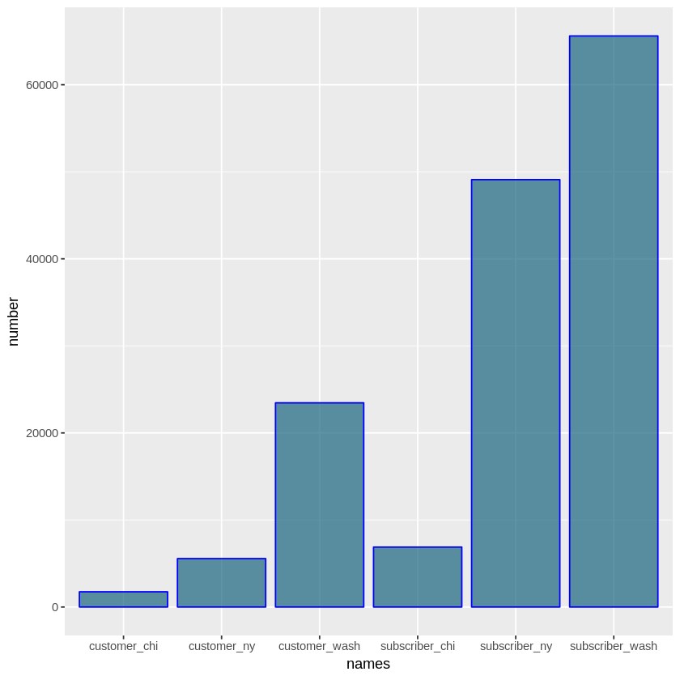

```r
# code of the graph:

 library (ggplot2)
customer_ny = 5558
subscriber_ny = 49093
customer_wash = 23450
subscriber_wash = 65600
customer_chi = 1746
subscriber_chi =6883

data <- data.frame(names =c("customer_ny","subscriber_ny","customer_wash","subscriber_wash","customer_chi","subscriber_chi"),number=c(5558, 49093,23450,65600,1746,6883))
data



ggplot(data, aes(x = names , y = number)) + geom_bar(stat ="identity", color="blue", fill=rgb(0.1,0.4,0.5,0.7) )
```

```r
#Code of the summary table:
summary.of.user.types.counts <- matrix(c(65600,23450,6883,1746,49093,5558),ncol=2,byrow=TRUE)
colnames(summary.of.user.types.counts) <- c("subscribers","customers")
rownames(summary.of.user.types.counts) <- c("Washington","Chicago","New.York")
summary.of.user.types.counts <- as.table(summary.of.user.types.counts)
summary.of.user.types.counts
```

```
           subscribers customers
Washington       65600     23450
Chicago           6883      1746
New.York         49093      5558
```

**In chicago table, the user types are divided into: customer= 1746 & subscriber= 6883. In washington table, the user types are divided into: customer= 23450 & subscriber= 65600. In new_york_city table, the user types are divided into: customer= 5558 & subscriber= 49093**

### Question 2

**What is the most common end station?**

```r
ny = read.csv('new_york_city.csv')
wash = read.csv('washington.csv')
chi = read.csv('chicago.csv')

table(wash$End.Station)
summary(wash$End.Station)
```

[output not shown]

[output cut: 902 more lines]

[output not shown]

**Columbus Circle / Union Station**

1767

**Jefferson Dr & 14th St SW**

1603

**Lincoln Memorial**

1514

**Massachusetts Ave & Dupont Circle NW**

1344

**Smithsonian-National Mall / Jefferson Dr & 12th St SW**

1103

**15th & P St NW**

1077

**Jefferson Memorial**

1026

**Henry Bacon Dr & Lincoln Memorial Circle NW**

929

**4th St & Madison Dr NW**

883

**14th & V St NW**

814

**5th & K St NW**

809

**New Hampshire Ave & T St NW**

791

**8th & H St NW**

756

**North Capitol St & F St NW**

753

**1st & M St NE**

750

**New York Ave & 15th St NW**

745

**14th & Rhode Island Ave NW**

743

**Eastern Market Metro / Pennsylvania Ave & 7th St SE**

740

**Thomas Circle**

715

**14th & R St NW**

702

**17th St & Independence Ave SW**

691

**Constitution Ave & 2nd St NW/DOL**

685

**M St & Pennsylvania Ave NW**

677

**5th St & Massachusetts Ave NW**

667

**21st & M St NW**

648

**14th & D St NW / Ronald Reagan Building**

646

**17th & Corcoran St NW**

643

**4th & M St SW**

643

**8th & O St NW**

636

**17th & G St NW**

631

**17th & K St NW**

623

**17th & K St NW / Farragut Square**

619

**7th & T St NW**

611

**18th & R St NW**

606

**20th St & Florida Ave NW**

598

**M St & Delaware Ave NE**

572

**Georgetown Harbor / 30th St NW**

570

**Metro Center / 12th & G St NW**

568

**17th St & Massachusetts Ave NW**

556

**Ohio Dr & West Basin Dr SW / MLK & FDR Memorials**

556

**4th & E St SW**

548

**11th & M St NW**

541

**Washington & Independence Ave SW/HHS**

531

**10th St & Constitution Ave NW**

525

**14th & G St NW**

525

**20th & O St NW / Dupont South**

522

**4th & C St SW**

522

**1st & K St SE**

516

**Lynn & 19th St North**

514

**8th & D St NW**

512

**3rd & H St NE**

509

**L'Enfant Plaza / 7th & C St SW**

497

**Adams Mill & Columbia Rd NW**

491

**New Hampshire Ave & 24th St NW**

490

**California St & Florida Ave NW**

487

**13th St & New York Ave NW**

481

**22nd & I St NW / Foggy Bottom**

480

**25th St & Pennsylvania Ave NW**

476

**Convention Center / 7th & M St NW**

474

**21st & I St NW**

466

**10th & K St NW**

457

**Calvert St & Woodley Pl NW**

454

**6th St & Indiana Ave NW**

451

**3rd & Tingey St SE**

450

**C & O Canal & Wisconsin Ave NW**

450

**5th & F St NW**

449

**12th & U St NW**

448

**3rd St & Pennsylvania Ave SE**

434

**7th & R St NW / Shaw Library**

434

**15th & K St NW**

431

**6th & H St NE**

428

**10th & U St NW**

421

**24th & N St NW**

421

**USDA / 12th & Independence Ave SW**

420

**18th & M St NW**

418

**8th & F St NW**

417

**10th & E St NW**

413

**2nd St & Massachusetts Ave NE**

413

**15th & W St NW**

406

**18th St & Wyoming Ave NW**

404

**1st & Rhode Island Ave NW**

404

**14th & Belmont St NW**

403

**2nd & G St NE**

399

**Lincoln Park / 13th & East Capitol St NE**

392

**22nd & P ST NW**

378

**15th & L St NW**

376

**4th & East Capitol St NE**

376

**34th & Water St NW**

374

**Eastern Market / 7th & North Carolina Ave SE**

371

**14th & Irving St NW**

369

**14th St & New York Ave NW**

364

**13th & H St NE**

358

**18th St & Pennsylvania Ave NW**

346

**11th & Kenyon St NW**

343

**10th & G St NW**

338

**Park Rd & Holmead Pl NW**

336

**16th & R St NW**

329

**14th & L St NW**

328

**11th & O St NW**

327

**(Other)**

31404

```r
#ً chicago
table(chi$End.Station)
summary(chi$End.Station)

#ً new_york_city
table(ny$End.Station)
summary(ny$End.Station)
```

[output not shown]

[output not shown]

[output cut: 417 more lines]

[output not shown]

**Streeter Dr & Grand Ave**

233

**Clinton St & Madison St**

145

**Theater on the Lake**

131

**Lake Shore Dr & Monroe St**

115

**Clinton St & Washington Blvd**

109

**Lake Shore Dr & North Blvd**

102

**Michigan Ave & Oak St**

102

**Canal St & Madison St**

98

**Canal St & Adams St**

91

**Kingsbury St & Kinzie St**

90

**Michigan Ave & Washington St**

90

**Millennium Park**

83

**Dearborn St & Erie St**

71

**Clinton St & Jackson Blvd**

68

**Franklin St & Monroe St**

68

**Orleans St & Merchandise Mart Plaza**

68

**Wabash Ave & Roosevelt Rd**

68

**Daley Center Plaza**

64

**McClurg Ct & Illinois St**

64

**Dearborn St & Monroe St**

61

**Shedd Aquarium**

61

**St. Clair St & Erie St**

60

**Clark St & Elm St**

59

**Franklin St & Jackson Blvd**

57

**Indiana Ave & Roosevelt Rd**

57

**Fairbanks Ct & Grand Ave**

56

**LaSalle St & Jackson Blvd**

55

**Burnham Harbor**

54

**Damen Ave & Pierce Ave**

53

**Michigan Ave & Lake St**

53

**Wabash Ave & Grand Ave**

53

**Dusable Harbor**

52

**LaSalle St & Illinois St**

52

**Adler Planetarium**

50

**Clinton St & Lake St**

50

**Columbus Dr & Randolph St**

49

**Larrabee St & Kingsbury St**

49

**Broadway & Barry Ave**

48

**Wacker Dr & Washington St**

48

**Marshfield Ave & Cortland St**

47

**Clark St & Armitage Ave**

46

**Morgan St & Lake St**

46

**Clark St & Lake St**

45

**Green St & Randolph St**

45

**Peoria St & Jackson Blvd**

44

**State St & Kinzie St**

43

**Kingsbury St & Erie St**

42

**Wells St & Concord Ln**

42

**McClurg Ct & Erie St**

41

**Michigan Ave & Jackson Blvd**

41

**Clark St & Lincoln Ave**

39

**Wells St & Huron St**

39

**State St & Randolph St**

38

**Wilton Ave & Belmont Ave**

38

**Ashland Ave & Division St**

37

**Franklin St & Quincy St**

37

**Canal St & Monroe St (*)**

36

**Dearborn Pkwy & Delaware Pl**

36

**Desplaines St & Kinzie St**

36

**Lakeview Ave & Fullerton Pkwy**

35

**Bissell St & Armitage Ave**

34

**Clark St & Randolph St**

34

**Lake Shore Dr & Belmont Ave**

34

**State St & Van Buren St**

34

**Lake Shore Dr & Wellington Ave**

33

**Orleans St & Ohio St**

33

**Sheffield Ave & Webster Ave**

33

**Damen Ave & Chicago Ave**

32

**LaSalle St & Washington St**

32

**Sheffield Ave & Fullerton Ave**

32

**Sheffield Ave & Waveland Ave**

32

**Sheridan Rd & Irving Park Rd**

32

**Wabash Ave & Wacker Pl**

32

**Clark St & Wrightwood Ave**

31

**Green St & Madison St**

31

**LaSalle St & Adams St**

31

**Rush St & Hubbard St**

31

**Sedgwick St & North Ave**

31

**Wells St & Elm St**

31

**Broadway & Belmont Ave**

30

**Clark St & Wellington Ave**

30

**Dearborn St & Adams St**

30

**Lake Shore Dr & Ohio St**

30

**Southport Ave & Roscoe St**

30

**Wells St & Evergreen Ave**

30

**Federal St & Polk St**

29

**Hampden Ct & Diversey Pkwy**

29

**Lake Shore Dr & Diversey Pkwy**

29

**Mies van der Rohe Way & Chestnut St**

29

**Montrose Harbor**

29

**Sheffield Ave & Kingsbury St**

29

**Wabash Ave & 16th St**

29

**Wood St & Milwaukee Ave**

29

**Aberdeen St & Jackson Blvd**

28

**Aberdeen St & Monroe St**

28

**Broadway & Cornelia Ave**

28

**Franklin St & Chicago Ave**

28

**Halsted St & Blackhawk St (*)**

28

**Halsted St & Diversey Pkwy**

28

**(Other)**

3647

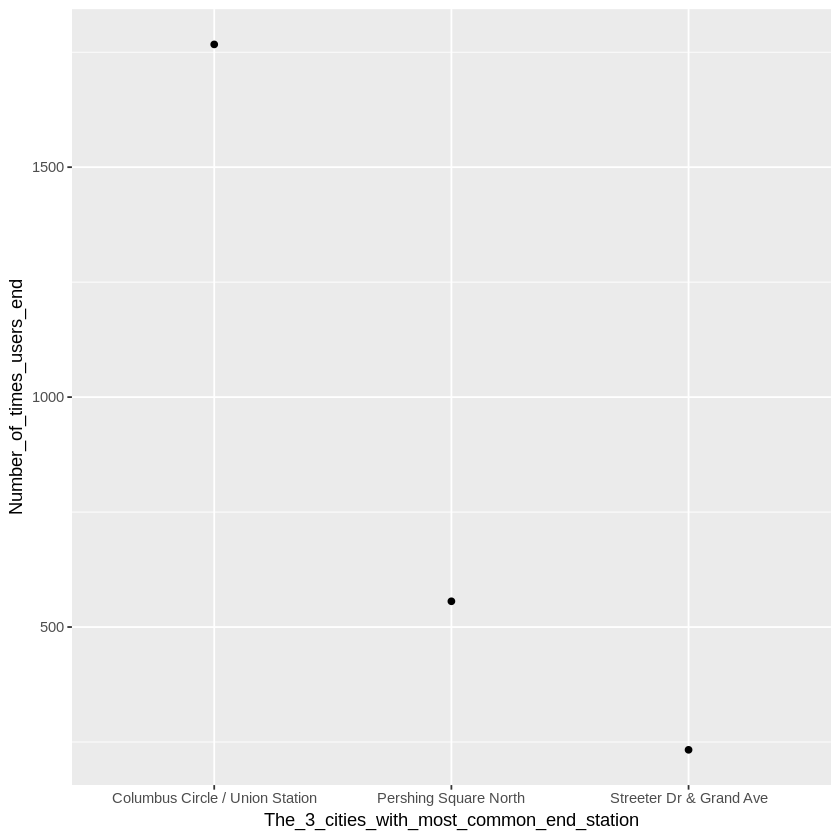

```r
End_station <-data.frame(The_3_cities_with_most_common_end_station=c("Columbus Circle / Union Station","Pershing Square North","Streeter Dr & Grand Ave") ,Number_of_times_users_end =c(1767,556,233) )

library(ggplot2)
ggplot(End_station, aes(x=The_3_cities_with_most_common_end_station, y=Number_of_times_users_end)) +
  geom_point()
```

# Code of summary table:

summary.of.most.common.end.stations <- matrix(c(1767,NA,NA,NA,233,NA,NA,NA,556),ncol=3,byrow=TRUE) colnames(summary.of.most.common.end.stations) <- c("Columbus.Circle/Union.Station","Streeter.Dr&Grand.Ave","Pershing.Square.North") rownames(summary.of.most.common.end.stations) <- c("Washington","Chicago","New.York") summary.of.most.common.end.stations <- as.table(summary.of.most.common.end.stations) summary.of.most.common.end.stations

**The most common end station in washington is = Columbus Circle / Union Station (1767 times). The most common end station in chicago is = Streeter Dr & Grand Ave (233 times). The most common end station in new_york_city is = Pershing Square North (556 times)**

### Question 3

**What is the most common start station?**

```r
#chicago
table(chi$Start.Station)
summary(chi$Start.Station)
```

[output not shown]

[output cut: 417 more lines]

[output not shown]

**Streeter Dr & Grand Ave**

210

**Lake Shore Dr & Monroe St**

140

**Clinton St & Washington Blvd**

120

**Clinton St & Madison St**

102

**Canal St & Adams St**

101

**Michigan Ave & Oak St**

98

**Canal St & Madison St**

87

**Columbus Dr & Randolph St**

85

**Lake Shore Dr & North Blvd**

85

**Franklin St & Monroe St**

81

**Kingsbury St & Kinzie St**

79

**Michigan Ave & Washington St**

79

**McClurg Ct & Illinois St**

77

**Theater on the Lake**

77

**Michigan Ave & Lake St**

73

**Millennium Park**

73

**Clinton St & Jackson Blvd**

65

**Shedd Aquarium**

63

**LaSalle St & Jackson Blvd**

60

**Orleans St & Merchandise Mart Plaza**

58

**Daley Center Plaza**

57

**Dearborn St & Erie St**

57

**Wells St & Concord Ln**

57

**Clark St & Armitage Ave**

56

**Indiana Ave & Roosevelt Rd**

56

**Dusable Harbor**

55

**Franklin St & Jackson Blvd**

55

**Kingsbury St & Erie St**

54

**Clinton St & Lake St**

53

**Clark St & Elm St**

52

**Canal St & Monroe St (*)**

51

**Desplaines St & Kinzie St**

50

**Adler Planetarium**

49

**Dearborn St & Monroe St**

48

**Lake Shore Dr & Ohio St**

46

**Wabash Ave & Roosevelt Rd**

46

**Fairbanks Ct & Grand Ave**

45

**Larrabee St & Kingsbury St**

45

**LaSalle St & Illinois St**

45

**Montrose Harbor**

45

**Ravenswood Ave & Lawrence Ave**

45

**Clark St & Randolph St**

44

**St. Clair St & Erie St**

44

**Burnham Harbor**

43

**LaSalle St & Washington St**

43

**Dearborn Pkwy & Delaware Pl**

42

**State St & Van Buren St**

42

**Lake Shore Dr & Belmont Ave**

41

**Stetson Ave & South Water St**

41

**Buckingham Fountain**

40

**Clark St & Lincoln Ave**

40

**Lake Shore Dr & Wellington Ave**

40

**Marshfield Ave & Cortland St**

40

**McClurg Ct & Erie St**

40

**Michigan Ave & Jackson Blvd**

40

**Franklin St & Lake St**

39

**Peoria St & Jackson Blvd**

39

**State St & Pearson St**

39

**Financial Pl & Congress Pkwy**

38

**Franklin St & Quincy St**

38

**Green St & Randolph St**

38

**State St & Randolph St**

38

**Dearborn St & Adams St**

37

**Lakeview Ave & Fullerton Pkwy**

37

**Broadway & Barry Ave**

36

**Clark St & Lake St**

36

**Morgan St & Polk St**

36

**Sedgwick St & Webster Ave**

36

**Wabash Ave & Grand Ave**

36

**Wilton Ave & Belmont Ave**

36

**Wood St & Milwaukee Ave**

36

**Morgan St & Lake St**

35

**Wabash Ave & Wacker Pl**

35

**Wacker Dr & Washington St**

35

**Ashland Ave & Division St**

34

**Broadway & Cornelia Ave**

34

**Sheffield Ave & Wellington Ave**

34

**Sheridan Rd & Irving Park Rd**

34

**California Ave & Milwaukee Ave**

33

**Orleans St & Ohio St**

33

**Rush St & Hubbard St**

33

**Wabash Ave & 8th St**

33

**Wabash Ave & Adams St**

33

**Sheffield Ave & Waveland Ave**

32

**Southport Ave & Waveland Ave**

32

**Southport Ave & Wellington Ave**

32

**Clark St & Schiller St**

31

**Halsted St & Roscoe St**

31

**Sheffield Ave & Fullerton Ave**

31

**Federal St & Polk St**

30

**Wolcott Ave & Polk St**

30

**Damen Ave & Pierce Ave**

29

**Jefferson St & Monroe St**

29

**MLK Jr Dr & 29th St**

29

**Pine Grove Ave & Irving Park Rd**

29

**Sheffield Ave & Webster Ave**

29

**State St & Kinzie St**

29

**Wells St & Evergreen Ave**

29

**Dayton St & North Ave**

28

**(Other)**

3689

```r
#washington
table(wash$Start.Station)
summary(wash$Start.Station)
```

[output not shown]

[output cut: 900 more lines]

[output not shown]

**Columbus Circle / Union Station**

1700

**Lincoln Memorial**

1546

**Jefferson Dr & 14th St SW**

1488

**Massachusetts Ave & Dupont Circle NW**

1219

**Jefferson Memorial**

1068

**15th & P St NW**

1040

**Smithsonian-National Mall / Jefferson Dr & 12th St SW**

1010

**Henry Bacon Dr & Lincoln Memorial Circle NW**

910

**4th St & Madison Dr NW**

894

**Eastern Market Metro / Pennsylvania Ave & 7th St SE**

823

**Thomas Circle**

823

**14th & V St NW**

821

**New Hampshire Ave & T St NW**

769

**17th St & Independence Ave SW**

752

**5th & K St NW**

738

**8th & H St NW**

724

**North Capitol St & F St NW**

721

**1st & M St NE**

706

**14th & Rhode Island Ave NW**

697

**14th & R St NW**

667

**New York Ave & 15th St NW**

656

**Constitution Ave & 2nd St NW/DOL**

651

**17th & Corcoran St NW**

619

**5th St & Massachusetts Ave NW**

615

**7th & T St NW**

611

**8th & O St NW**

608

**21st & M St NW**

597

**Adams Mill & Columbia Rd NW**

595

**14th & D St NW / Ronald Reagan Building**

589

**4th & M St SW**

580

**14th & Irving St NW**

558

**20th St & Florida Ave NW**

557

**18th & R St NW**

550

**Metro Center / 12th & G St NW**

548

**17th & G St NW**

540

**M St & Delaware Ave NE**

532

**17th & K St NW**

531

**11th & M St NW**

529

**M St & Pennsylvania Ave NW**

522

**17th St & Massachusetts Ave NW**

520

**4th & E St SW**

517

**22nd & I St NW / Foggy Bottom**

514

**L'Enfant Plaza / 7th & C St SW**

511

**14th & G St NW**

508

**Ohio Dr & West Basin Dr SW / MLK & FDR Memorials**

496

**3rd & H St NE**

494

**3rd St & Pennsylvania Ave SE**

484

**Convention Center / 7th & M St NW**

481

**New Hampshire Ave & 24th St NW**

479

**10th St & Constitution Ave NW**

478

**17th & K St NW / Farragut Square**

477

**Washington & Independence Ave SW/HHS**

475

**Calvert St & Woodley Pl NW**

473

**18th St & Wyoming Ave NW**

469

**20th & O St NW / Dupont South**

467

**1st & K St SE**

465

**8th & D St NW**

463

**10th & U St NW**

460

**2nd St & Massachusetts Ave NE**

457

**25th St & Pennsylvania Ave NW**

450

**California St & Florida Ave NW**

447

**12th & U St NW**

443

**4th & C St SW**

442

**Lincoln Park / 13th & East Capitol St NE**

435

**10th & K St NW**

434

**6th St & Indiana Ave NW**

433

**USDA / 12th & Independence Ave SW**

433

**16th & Harvard St NW**

431

**7th & R St NW / Shaw Library**

423

**11th & Kenyon St NW**

421

**14th & Belmont St NW**

420

**4th & East Capitol St NE**

410

**18th St & Pennsylvania Ave NW**

403

**18th & M St NW**

393

**15th & W St NW**

392

**1st & Rhode Island Ave NW**

390

**22nd & P ST NW**

390

**15th & K St NW**

387

**Park Rd & Holmead Pl NW**

387

**6th & H St NE**

386

**Georgetown Harbor / 30th St NW**

382

**Eastern Market / 7th & North Carolina Ave SE**

379

**5th & F St NW**

377

**21st & I St NW**

372

**11th & O St NW**

364

**16th & R St NW**

363

**15th & L St NW**

362

**3rd & Tingey St SE**

356

**10th & E St NW**

355

**8th & F St NW**

355

**Lynn & 19th St North**

355

**C & O Canal & Wisconsin Ave NW**

353

**24th & N St NW**

352

**13th & D St NE**

349

**14th & L St NW**

344

**37th & O St NW / Georgetown University**

344

**13th & H St NE**

341

**Columbia Rd & Belmont St NW**

334

**2nd & G St NE**

333

**(Other)**

33739

```r
# new_ork_city
table(ny$Start.Station)
summary(ny$Start.Station)
```

[output not shown]

[output cut: 1216 more lines]

[output not shown]

**Pershing Square North**

592

**W 21 St & 6 Ave**

385

**Broadway & E 22 St**

383

**E 17 St & Broadway**

380

**West St & Chambers St**

364

**W 20 St & 11 Ave**

329

**8 Ave & W 31 St**

316

**8 Ave & W 33 St**

302

**W 41 St & 8 Ave**

292

**Greenwich Ave & 8 Ave**

288

**Carmine St & 6 Ave**

281

**Central Park S & 6 Ave**

279

**Grand Army Plaza & Central Park S**

279

**University Pl & E 14 St**

279

**9 Ave & W 22 St**

278

**W 31 St & 7 Ave**

277

**W 18 St & 6 Ave**

270

**Centre St & Chambers St**

266

**W 38 St & 8 Ave**

263

**Great Jones St**

262

**12 Ave & W 40 St**

261

**6 Ave & W 33 St**

252

**Cooper Square & E 7 St**

243

**Cleveland Pl & Spring St**

238

**E 7 St & Avenue A**

237

**South End Ave & Liberty St**

235

**Lafayette St & E 8 St**

233

**W 27 St & 7 Ave**

231

**E 47 St & Park Ave**

225

**Broadway & E 14 St**

224

**Christopher St & Greenwich St**

224

**Lafayette St & Jersey St**

224

**W 33 St & 7 Ave**

221

**E 10 St & Avenue A**

220

**Broadway & W 29 St**

219

**Grand St & Elizabeth St**

219

**W 13 St & Hudson St**

219

**Broadway & W 58 St**

216

**Lexington Ave & E 24 St**

216

**1 Ave & E 16 St**

214

**E 15 St & 3 Ave**

214

**W 43 St & 6 Ave**

213

**11 Ave & W 27 St**

212

**W 24 St & 7 Ave**

212

**Barrow St & Hudson St**

211

**E 16 St & 5 Ave**

211

**E 32 St & Park Ave**

211

**E 33 St & 2 Ave**

211

**W 16 St & The High Line**

211

**W 25 St & 6 Ave**

209

**E 14 St & Avenue B**

207

**Vesey Pl & River Terrace**

207

**W 26 St & 8 Ave**

207

**Broadway & W 24 St**

199

**E 39 St & 2 Ave**

199

**Broadway & W 49 St**

198

**W 22 St & 8 Ave**

197

**E 24 St & Park Ave S**

196

**LaGuardia Pl & W 3 St**

196

**MacDougal St & Prince St**

195

**W 52 St & 5 Ave**

195

**Broadway & W 60 St**

193

**E 11 St & 2 Ave**

193

**1 Ave & E 18 St**

192

**1 Ave & E 68 St**

192

**W 52 St & 6 Ave**

192

**9 Ave & W 45 St**

191

**W 15 St & 7 Ave**

191

**W 13 St & 6 Ave**

188

**Allen St & Rivington St**

187

**8 Ave & W 16 St**

184

**Broadway & W 32 St**

184

**E 33 St & 5 Ave**

180

**E 20 St & 2 Ave**

179

**W 27 St & 10 Ave**

178

**E 2 St & Avenue B**

176

**Sullivan St & Washington Sq**

176

**E 25 St & 2 Ave**

175

**Mercer St & Bleecker St**

175

**Mott St & Prince St**

175

**W 49 St & 8 Ave**

175

**Amsterdam Ave & W 73 St**

174

**Little West St & 1 Pl**

174

**St Marks Pl & 2 Ave**

174

**Allen St & Stanton St**

173

**E 23 St & 1 Ave**

173

**Barclay St & Church St**

172

**Broadway & W 41 St**

172

**E 48 St & 5 Ave**

171

**W 26 St & 10 Ave**

171

**W Broadway & Spring St**

171

**E 13 St & Avenue A**

170

**Pershing Square South**

170

**W 20 St & 7 Ave**

170

**Canal St & Rutgers St**

168

**Suffolk St & Stanton St**

168

**E 39 St & 3 Ave**

167

**W 44 St & 5 Ave**

167

**1 Ave & E 30 St**

166

**(Other)**

32776

| The_3_cities_with_most_common_start_station | Number_of_times_users_start |
| --- | --- |
| Columbus Circle / Union Station | 1700 |
| Pershing Square North | 592 |
| Streeter Dr & Grand Ave | 210 |

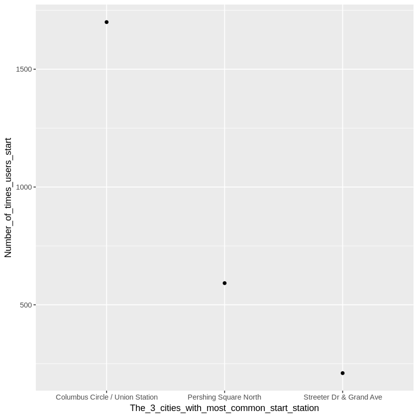

```r
start_station <-data.frame(The_3_cities_with_most_common_start_station=c("Columbus Circle / Union Station","Pershing Square North","Streeter Dr & Grand Ave") ,Number_of_times_users_start =c(1700,592,210) )
 start_station
library(ggplot2)
ggplot(start_station, aes(x=The_3_cities_with_most_common_start_station, y=Number_of_times_users_start)) +
  geom_point()
```

# Code of summary table:

summary.of.most.common.start.stations <- matrix(c(1700,NA,NA,NA,210,NA,NA,NA,592),ncol=3,byrow=TRUE)

colnames(summary.of.most.common.start.stations) <- c("Columbus.Circle/Union.Station","Streeter.Dr&Grand.Ave","Pershing.Square.North")

rownames(summary.of.most.common.start.stations) <- c("Washington","Chicago","New.York")

summary.of.most.common.start.stations <- as.table(summary.of.most.common.start.stations) summary.of.most.common.start.stations

**The most common start station in chicago is = Streeter Dr & Grand Ave (210 times). The most common start station in washington is = Columbus Circle / Union Station (1700 times). The most common start station in new_york_city is = Pershing Square North (592 times)**

## Finishing Up

> Congratulations! You have reached the end of the Explore Bikeshare Data Project. You should be very proud of all you have accomplished!

> **Tip**: Once you are satisfied with your work here, check over your report to make sure that it is satisfies all the areas of the [rubric](https://review.udacity.com/#!/rubrics/2508/view).

## Directions to Submit

> Before you submit your project, you need to create a .html or .pdf version of this notebook in the workspace here. To do that, run the code cell below. If it worked correctly, you should get a return code of 0, and you should see the generated .html file in the workspace directory (click on the orange Jupyter icon in the upper left).

> Alternatively, you can download this report as .html via the **File** > **Download as** submenu, and then manually upload it into the workspace directory by clicking on the orange Jupyter icon in the upper left, then using the Upload button.

> Once you've done this, you can submit your project by clicking on the "Submit Project" button in the lower right here. This will create and submit a zip file with this .ipynb doc and the .html or .pdf version you created. Congratulations!

```r
system('python -m nbconvert Explore_bikeshare_data.ipynb')
```

/* End of code */